# Spatial Statistics - Introduction

```r
knitr::opts_chunk$set(echo = TRUE)

#install.packages("spatstat")
library(spatstat)
```

# Task 1: Simple spatial principles

For these first few exercises you’ll mostly use standard R functions to generate some point patterns.

First, you’ll generate 200 points distributed uniformly in a rectangle. The rectangle will have its bottom left corner at coordinate `(0, 0)` and its top right corner at `(1, 2)`, so it is taller than it is wide.

`runif(n, a, b)` will generate `n` random numbers anywhere between `a` and `b`.

## Create some points

- Set the minimum and maximum values of the rectangle in X and Y coordinates.
- Complete the call to `runif()` to create the X coordinates, and write the similar line for the Y coordinates. Note that `n` is already defined for you.

```r
n = 200

xmin <- 0
xmax <- 1
ymin <- 0
ymax <- 2

x = runif(n, xmin, xmax)
y = runif(n, ymin, ymax)
```

# Task 2: Plotting areas

At school you may have been taught to make the most of a piece of graph paper by scaling data to fit the page. R will usually follow this advice by making a plot fill the graphics window.

With spatial data, this can cause misleading distortion that changes the distance and direction between pairs of points. The data in the previous exercise was created in a tall, skinny rectangle, and it should always be shown as a tall, skinny rectangle. If R stretches this to fill a wide graphics window then it is misrepresenting the relationship between events in the up-down and left-right directions.

So spatial plots should have scales so that one unit in the X axis is the same size as one unit on the Y axis. Circles will appear as circles and not ellipses, and squares will appear square.

The ratio of the Y axis scale to the X axis scale is called the *aspect ratio* of the plot. Spatial data should always be presented with an aspect ratio of 1:1.

## Instructions

The boundaries of the rectangle have been pre-defined as `xmin`, `xmax`, `ymin`, and `ymax`. The x and y coordinates of the points have been pre-defined as `x` and `y`, respectively.

- Edit the body of the `mapxy()` function to plot the points using the `x` and `y` vectors.
- Call `mapxy()` with the correct aspect ratio a to get the map looking right. You should get points in a rectangle twice as high as it is wide.

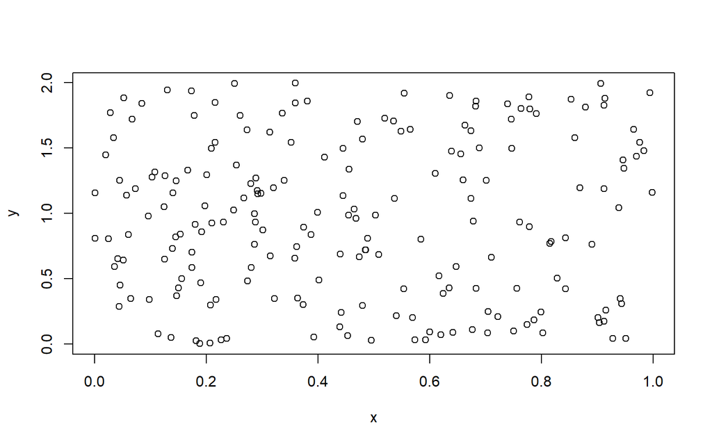

```r
plot(x,y)
```

```r
ls.str()
```

```
## n :  num 200
## x :  num [1:200] 0.906 0.503 0.879 0.746 0.18 ...
## xmax :  num 1
## xmin :  num 0
## y :  num [1:200] 1.995 0.986 1.814 1.721 0.916 ...
## ymax :  num 2
## ymin :  num 0
```

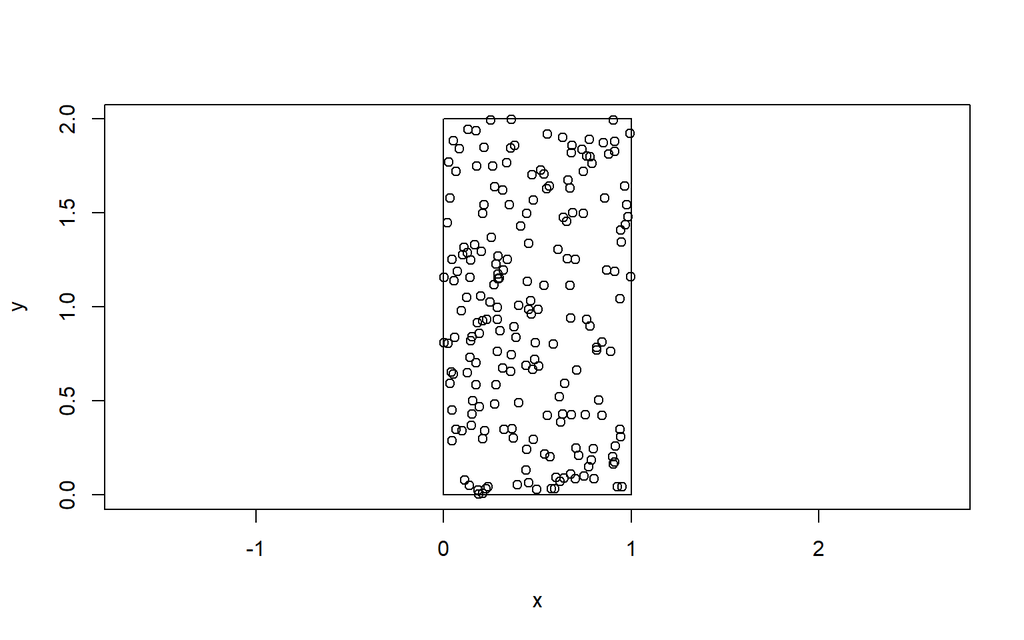

```r
mapxy <- function(a = NA){
  plot(x, y, asp = a)
  rect(xmin, ymin, xmax, ymax)
}

mapxy(1:1)
```

Aha! Forcing the aspect ratio to 1 should prevent the distortion of areas.

# Task 3: Uniform pattern in a circle

Remember those regularly spaced US or Vietnamese farmhouses when seen from birds’ eye view? Land use boundaries can survive in the landscape long after the actual divisions are gone, and can tell you about allocation of resources and the rule of law in a country. Let’s look how these regular, or uniform patterns are created.

How do we create a uniform density point pattern in a circle? We might first try selecting radius and angle uniformly. But that produces a “cluster” at small distances. Instead we sample the radius from a non-uniform distribution that scales linearly with distance, so we have fewer points at small radii and more at large radii.

This exercise uses `spatstat`’s *`disc()`* function, that creates a circular window.

The number of points to generate and the circle’s radius are shown in the script as n_points and radius respectively.

## Instructions

- Call `library()` to load the `spatstat` package.
- Create `n_points` random numbers uniformly from zero to the radius-squared. Assign the result to `r_squared`.
- Calculate the `x` and `y` coordinates.
  - `x`-values are the square root of `r_squared` times the cosine of `angle`.
  - `y`-values are the square root of `r_squared` times the sine of `angle`.
- Plot a disc of radius `radius`, then add the points to the plot.

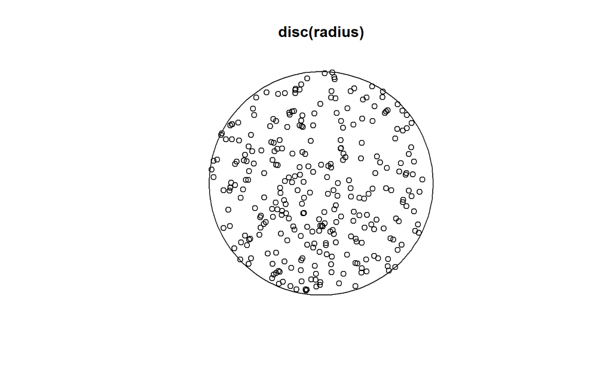

```r
# Load the spatstat package
#see above

# Create this many points, in a circle of this radius
n_points <- 300
radius <- 10

# Generate uniform random numbers up to radius-squared using the objects above
r_squared <- runif(n_points, 0, radius^2)
angle <- runif(n_points, 0, 2*pi)

# Take the square root of the values to get a uniform spatial distribution
x <- sqrt(r_squared) * cos(angle)
y <- sqrt(r_squared) * sin(angle)

plot(disc(radius)); points(x, y)
```

# Task 4: Quadrat count test for randomness

Humans tend to see patterns in random arrangements, so we need statistical tests. The quadrat count test was one of the earliest developed spatial statistics methods. It can be used to check if points are completely spatially random; that is, they are uniformly random throughout the area of interest. By running a quadrat count test on the points generated in the previous exercise, you can confirm they were generated uniformly on the circle.

Quadrat count tests are implemented using `quadrat.test()`, which takes a planar point pattern, `ppp()` object. “Planar point pattern” is jargon for a set of points in a region of a 2D plane

## Instructions

The variables x, y, and radius are set for you.

- Create a new `spatstat` planar point-pattern object
- Pass the pre-defined x and y values.
- Use a `disc()` of the right radius as the window.
- Run the quadrat count test.
- Plot and print the results. In the plot you’ll see the observed and expected number of points in each quadrat as well as a measure of how far above or below the expected number is.
- **Does the p-value let you reject the null hypothesis?**

```r
# Some variables have been pre-defined
ls.str()
```

```
## angle :  num [1:300] 1.09 4.82 6.06 1 2.56 ...
## mapxy : function (a = NA)
## n :  num 200
## n_points :  num 300
## r_squared :  num [1:300] 95.88 6.78 18.77 46.9 90.48 ...
## radius :  num 10
## x :  num [1:300] 4.558 0.271 4.225 3.688 -7.924 ...
## xmax :  num 1
## xmin :  num 0
## y :  num [1:300] 8.666 -2.59 -0.961 5.771 5.262 ...
## ymax :  num 2
## ymin :  num 0
```

```r
x <-  runif(300, -10,10)
y <-  runif(300, -10,10)
radius <- 10

summary(x)
```

```
##    Min. 1st Qu.  Median    Mean 3rd Qu.    Max.
## -9.8829 -5.3686 -0.4801 -0.1894  4.8990  9.8884
```

```r
# Set coordinates and window
ppxy <- ppp(x = x, y = y, window = disc(radius))
```

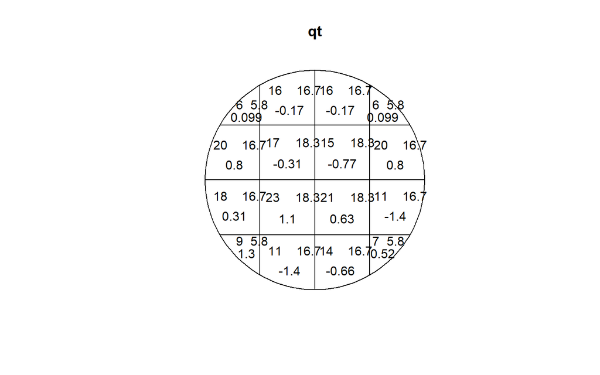

```r
# Test the point pattern
qt <- quadrat.test(ppxy, nx = 4, ny = 4) #reduce from 5 to 4, can make more squares e.g 7x7

# Inspect the results
plot(qt)
```

```r
print(qt)
```

```
##
##  Chi-squared test of CSR using quadrat counts
##
## data:  ppxy
## X2 = 10.191, df = 15, p-value = 0.3849
## alternative hypothesis: two.sided
##
## Quadrats: 16 tiles (irregular windows)
```

# Task 5: Creating a random point pattern with spatstat

A *Poisson* point process creates events according to a Poisson distribution with an intensity parameter specifying the expected events per unit area. The total number of events generated is a single number from a Poisson distribution, so multiple realizations of the same process can easily have different numbers of events.

The `spatstat` package can generate Poisson spatial processes with the `rpoispp()` function given an intensity and a window, that are not conditioned on the total.

Just as the random number generator functions in R start with an “r”, most of the random point-pattern functions in `spatstat` start with an “r”.

The `area.owin()` function of `spatstat` will compute the area of a window such as a disc.

## Instructions

- Create a disc of radius 10, assigning the result to `disc10`.
- To generate approximately 500 points in a disc of radius 10, set `lambda` to 500 divided by the `area.owin()` of the disc. Assign the result to `lambda`.
- Generate a random Poisson point pattern with intensity `lambda` and window `disc10`, assigning the result to `ppois`. Do you get about 500 points?
- Plot the Poisson point pattern by calling `plot()` on `ppois`.

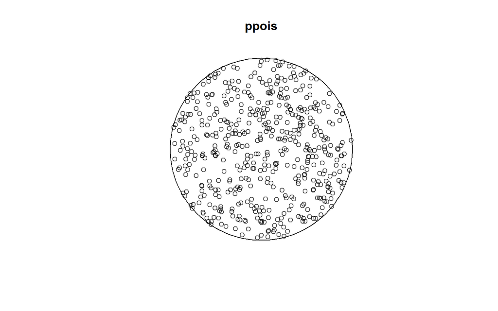

```r
# Create a disc of radius 10
disc10 <- disc(10)

# Compute the rate as count divided by area
lambda <- 500 / area.owin(disc10)

# Create a point pattern object
ppois <- rpoispp(lambda = lambda, win = disc10)

# Plot the Poisson point pattern
plot(ppois)
```

Perfect Poisson process plotting! Poisson processes generate completely spatially random points. Next you’ll see some other processes for generating random points.

# Task 6: Simulating clustered and inhibitory patterns

The `spatstat` package also has functions for generating point patterns from other process models. These generally fall into one of two classes: clustered processes, where points occur together more than under a uniform Poisson process, and regular (aka inhibitory) processes where points are more spaced apart than under a uniform intensity Poisson process. Some process models can generate patterns on a continuum from clustered through uniform to regular depending on their parameters.

The `quadrat.test()` function can test against clustered or regular alternative hypotheses. By default it tests against either of those, but this can be changed with the `alternative` parameter to create a one-sided test.

A *Thomas* process is a clustered pattern where a number of “parent” points, uniformly distributed, create a number of “child” points in their neighborhood. The child points themselves form the pattern. This is an *attractive* point pattern, and makes sense for modeling things like trees, since new trees will grow near the original tree. Random Thomas point patterns can be generated using `rThomas()`. This takes three numbers that determine the intensity and clustering of the points, and a window object.

Conversely the points of a *Strauss* process cause a lowering in the probability of finding another point nearby. The parameters of a Strauss process can be such that it is a “hard-core” process, where no two points can be closer than a set threshold. Creating points from this process involves some clever simulation algorithms. This is a *repulsive* point pattern, and makes sense for modeling things like territorial animals, since the other animals of that species will avoid the territory of a given animal. Random Strauss point patterns can be generated using `rStrauss()`. This takes three numbers that determine the intensity and “territory” of the points, and a window object. Points generated by a Strauss process are sometimes called *regularly* spaced.